# Week 5 - Separating Spam from Ham

Vishal Gupta

3/30/2019

```r
library(dplyr)
library(rpart)
library(rpart.plot)
library(caTools)
library(ROCR)
library(randomForest)
library(tm)
library(SnowballC)
```

#### Problem 1.1 - Loading the Dataset

Begin by loading the dataset emails.csv into a data frame called emails. Remember to pass the stringsAsFactors=FALSE option when loading the data.

How many emails are in the dataset?

```r
emails = read.csv("~/Downloads/emails.csv")
nrow(emails)
```

```
## [1] 5728
```

#### Problem 1.2 - Loading the Dataset

How many of the emails are spam?

```r
table(emails$spam)
```

```
##
##    0    1
## 4360 1368
```

#### Problem 1.3 - Loading the Dataset

Which word appears at the beginning of every email in the dataset? Respond as a lower-case word with punctuation removed.

```r
head(emails$text)
```

```
## [1] Subject: naturally irresistible your corporate identity  lt is really hard to recollect a company : the  market is full of suqgestions and the information isoverwhelminq ; but a good  catchy logo , stylish statlonery and outstanding website  will make the task much easier .  we do not promise…
## [2] Subject: the stock trading gunslinger  fanny is merrill but muzo not colza attainder and penultimate like esmark perspicuous ramble is segovia not group try slung kansas tanzania yes chameleon or continuant clothesman no  libretto is chesapeake but tight not waterway herald and hawthorn like …
## [3] Subject: unbelievable new homes made easy  im wanting to show you this  homeowner  you have been pre - approved for a $ 454 , 169 home loan at a 3 . 72 fixed rate .  this offer is being extended to you unconditionally and your credit is in no way a factor .  to take advantage of this limited …
## [4] Subject: 4 color printing special  request additional information now ! click here  click here for a printable version of our order form ( pdf format )  phone : ( 626 ) 338 - 8090 fax : ( 626 ) 338 - 8102 e - mail : ramsey @ goldengraphix . com  request additional information now ! click here…
## [5] Subject: do not have money , get software cds from here !  software compatibility . . . . ain ' t it great ?  grow old along with me the best is yet to be .  all tradgedies are finish ' d by death . all comedies are ended by marriage .
## [6] Subject: great nnews  hello , welcome to medzonline sh groundsel op  we are pleased to introduce ourselves as one of the ieading online phar felicitation maceuticai shops .  helter v  shakedown r  a cosmopolitan l  l blister l  l bestow ag  ac tosher l  is coadjutor va  confidant um  andmanyo…
## 5695 Levels: Subject:   http : / / www . virtu  ally - anywhere . com / sports /  hello ,  i was hoping you could help me . the link above takes  you to  several  facility stadiumtours created by virtually  anywhere  interactive . i would  like to introduce the concept of a virtual tour to the  a…
```

#### Problem 1.4 - Loading the Dataset

Could a spam classifier potentially benefit from including the frequency of the word that appears in every email?

- No – the word appears in every email so this variable would not help us differentiate spam from ham.
- **Yes – the number of times the word appears might help us differentiate spam from ham.**

#### Problem 1.5 - Loading the Dataset

The nchar() function counts the number of characters in a piece of text. How many characters are in the longest email in the dataset (where longest is measured in terms of the maximum number of characters)?

```r
max(nchar(as.character(emails$text)))
```

```
## [1] 43952
```

#### Problem 1.6 - Loading the Dataset

Which row contains the shortest email in the dataset? (Just like in the previous problem, shortest is measured in terms of the fewest number of characters.)

```r
mail_len = nchar(as.character(emails$text))
which(mail_len==min(mail_len))
```

```
## [1] 1992
```

#### Problem 2.1 - Preparing the Corpus

Follow the standard steps to build and pre-process the corpus:

1. Build a new corpus variable called corpus.

```r
corpus = Corpus(VectorSource(emails$text))
```

2. Using tm_map, convert the text to lowercase.

```r
corpus = tm_map(corpus, tolower)
```

3. Using tm_map, remove all punctuation from the corpus.

```r
corpus = tm_map(corpus,removePunctuation)
```

4. Using tm_map, remove all English stopwords from the corpus.

```r
length(stopwords("english")) ==174
```

```
## [1] TRUE
```

```r
corpus = tm_map(corpus, removeWords, c(stopwords("english")))
```

5. Using tm_map, stem the words in the corpus.

```r
corpus = tm_map(corpus, stemDocument)
```

6. Build a document term matrix from the corpus, called dtm.

```r
dtm = DocumentTermMatrix(corpus)
```

If the code length(stopwords(“english”)) does not return 174 for you, then please run the line of code in this file, which will store the standard stop words in a variable called sw. When removing stop words, use tm_map(corpus, removeWords, sw) instead of tm_map(corpus, removeWords, stopwords(“english”)).

How many terms are in dtm?

```r
dim(dtm)[2]
```

```
## [1] 28687
```

#### Problem 2.2 - Preparing the Corpus

To obtain a more reasonable number of terms, limit dtm to contain terms appearing in at least 5% of documents, and store this result as spdtm (don’t overwrite dtm, because we will use it in a later step of this homework). How many terms are in spdtm?

```r
spdtm = removeSparseTerms(dtm, 1-5/100)
dim(spdtm)[2]
```

```
## [1] 330
```

#### Problem 2.3 - Preparing the Corpus

Build a data frame called emailsSparse from spdtm, and use the make.names function to make the variable names of emailsSparse valid.

colSums() is an R function that returns the sum of values for each variable in our data frame. Our data frame contains the number of times each word stem (columns) appeared in each email (rows). Therefore, colSums(emailsSparse) returns the number of times a word stem appeared across all the emails in the dataset. What is the word stem that shows up most frequently across all the emails in the dataset? Hint: think about how you can use sort() or which.max() to pick out the maximum frequency.

```r
emailsSparse = as.data.frame(as.matrix(spdtm),make.names)
colnames(emailsSparse) = paste0("W.", colnames(emailsSparse))
which.max(colSums(emailsSparse))
```

```
## W.enron
##     324
```

#### Problem 2.4 - Preparing the Corpus

Add a variable called “spam” to emailsSparse containing the email spam labels. You can do this by copying over the “spam” variable from the original data frame (remember how we did this in the Twitter lecture).

How many word stems appear at least 5000 times in the ham emails in the dataset? Hint: in this and the next question, remember not to count the dependent variable we just added.

```r
emailsSparse$spam = emails$spam
which(colSums(emailsSparse[emailsSparse$spam==0,])>5000)
```

```
## W.subject    W.will     W.ect     W.hou    W.vinc   W.enron
##        29        33       319       320       321       324
```

#### Problem 2.5 - Preparing the Corpus

How many word stems appear at least 1000 times in the spam emails in the dataset?

```r
which(colSums(emailsSparse[emailsSparse$spam==1,])>1000)
```

```
## W.compani W.subject    W.will      spam
##         3        29        33       331
```

#### Problem 2.6 - Preparing the Corpus

The lists of most common words are significantly different between the spam and ham emails. What does this likely imply?

- The frequencies of these most common words are unlikely to help differentiate between spam and ham.
- **The frequencies of these most common words are likely to help differentiate between spam and ham.**

#### Problem 2.7 - Preparing the Corpus

Several of the most common word stems from the ham documents, such as “enron”, “hou” (short for Houston), “vinc” (the word stem of “Vince”) and “kaminski”, are likely specific to Vincent Kaminski’s inbox. What does this mean about the applicability of the text analytics models we will train for the spam filtering problem?

- The models we build are still very general, and are likely to perform well as a spam filter for nearly any other person.
- **The models we build are personalized, and would need to be further tested before being used as a spam filter for another person.**

#### Problem 3.1 - Building machine learning models

First, convert the dependent variable to a factor with “emailsSparse$spam = as.factor(emailsSparse$spam)”.

```r
emailsSparse$spam = as.factor(emailsSparse$spam)
```

Next, set the random seed to 123 and use the sample.split function to split emailsSparse 70/30 into a training set called “train” and a testing set called “test”. Make sure to perform this step on emailsSparse instead of emails.

```r
set.seed(123)
spl = sample.split(emailsSparse$spam,0.7)
train= emailsSparse[spl==T,]
test= emailsSparse[spl==F,]
```

Using the training set, train the following three machine learning models. The models should predict the dependent variable “spam”, using all other available variables as independent variables. Please be patient, as these models may take a few minutes to train.

1. A logistic regression model called spamLog. You may see a warning message here - we’ll discuss this more later.

```r
spamLog = glm(spam ~ .,train,family = binomial)
```

```
## Warning: glm.fit: algorithm did not converge
```

```
## Warning: glm.fit: fitted probabilities numerically 0 or 1 occurred
```

2. A CART model called spamCART, using the default parameters to train the model (don’t worry about adding minbucket or cp). Remember to add the argument method=“class” since this is a binary classification problem.

```r
spamCART = rpart(spam ~ .,train,method = "class")
```

3. A random forest model called spamRF, using the default parameters to train the model (don’t worry about specifying ntree or nodesize). Directly before training the random forest model, set the random seed to 123 (even though we’ve already done this earlier in the problem, it’s important to set the seed right before training the model so we all obtain the same results. Keep in mind though that on certain operating systems, your results might still be slightly different).

```r
set.seed(123)
spamRF = randomForest(spam ~ .,train, method="class")
```

For each model, obtain the predicted spam probabilities for the training set. Be careful to obtain probabilities instead of predicted classes, because we will be using these values to compute training set AUC values. Recall that you can obtain probabilities for CART models by not passing any type parameter to the predict() function, and you can obtain probabilities from a random forest by adding the argument type=“prob”. For CART and random forest, you need to select the second column of the output of the predict() function, corresponding to the probability of a message being spam.

You may have noticed that training the logistic regression model yielded the messages “algorithm did not converge” and “fitted probabilities numerically 0 or 1 occurred”. Both of these messages often indicate overfitting and the first indicates particularly severe overfitting, often to the point that the training set observations are fit perfectly by the model. Let’s investigate the predicted probabilities from the logistic regression model.

How many of the training set predicted probabilities from spamLog are less than 0.00001?

```r
predLogTrain = predict(spamLog,train, type="response")
table(predLogTrain<0.00001)
```

```
##
## FALSE  TRUE
##   964  3046
```

How many of the training set predicted probabilities from spamLog are more than 0.99999?

```r
table(predLogTrain>0.99999)
```

```
##
## FALSE  TRUE
##  3056   954
```

How many of the training set predicted probabilities from spamLog are between 0.00001 and 0.99999?

```r
table((predLogTrain<=0.99999)&(predLogTrain>=0.00001))
```

```
##
## FALSE  TRUE
##  4000    10
```

#### Problem 3.2 - Building Machine Learning Models

How many variables are labeled as significant (at the p=0.05 level) in the logistic regression summary output?

```r
summary(spamLog)
```

```
##
## Call:
## glm(formula = spam ~ ., family = binomial, data = train)
##
## Deviance Residuals:
##    Min      1Q  Median      3Q     Max
## -1.011   0.000   0.000   0.000   1.354
##
## Coefficients:
##                Estimate Std. Error z value Pr(>|z|)
## (Intercept)  -3.082e+01  1.055e+04  -0.003    0.998
## W.busi       -4.803e+00  1.000e+04   0.000    1.000
## W.chang      -2.717e+01  2.215e+04  -0.001    0.999
## W.compani     4.781e+00  9.186e+03   0.001    1.000
## W.corpor     -8.286e-01  2.818e+04   0.000    1.000
## W.day        -6.100e+00  5.866e+03  -0.001    0.999
## W.done        6.828e+00  1.882e+04   0.000    1.000
## W.effect      1.948e+01  2.100e+04   0.001    0.999
## W.effort      1.606e+01  5.670e+04   0.000    1.000
## W.even       -1.654e+01  2.289e+04  -0.001    0.999
## W.full        2.125e+01  2.190e+04   0.001    0.999
## W.good        5.399e+00  1.619e+04   0.000    1.000
## W.inform      2.078e+01  8.549e+03   0.002    0.998
## W.interest    2.698e+01  1.159e+04   0.002    0.998
## W.list       -8.692e+00  2.149e+03  -0.004    0.997
## W.look       -7.031e+00  1.563e+04   0.000    1.000
## W.made        2.820e+00  2.743e+04   0.000    1.000
## W.make        2.901e+01  1.528e+04   0.002    0.998
## W.manag       6.014e+00  1.445e+04   0.000    1.000
## W.market      7.895e+00  8.012e+03   0.001    0.999
## W.much        3.775e-01  1.392e+04   0.000    1.000
## W.order       6.533e+00  1.242e+04   0.001    1.000
## W.origin      3.226e+01  3.818e+04   0.001    0.999
## W.product     1.016e+01  1.345e+04   0.001    0.999
## W.provid      2.422e-01  1.859e+04   0.000    1.000
## W.realli     -2.667e+01  4.640e+04  -0.001    1.000
## W.result     -5.002e-01  3.140e+04   0.000    1.000
## W.see        -1.120e+01  1.293e+04  -0.001    0.999
## W.special     1.777e+01  2.755e+04   0.001    0.999
## W.subject     3.041e+01  1.055e+04   0.003    0.998
```

[output cut: 294 more lines]

```
## W.enron      -8.789e+00  5.719e+03  -0.002    0.999
## W.kaminski   -1.812e+01  6.029e+03  -0.003    0.998
## W.713        -2.427e+01  2.914e+04  -0.001    0.999
## W.crenshaw    9.994e+01  6.769e+04   0.001    0.999
## W.vkamin     -6.649e+01  5.703e+04  -0.001    0.999
## W.gibner      2.901e+01  2.460e+04   0.001    0.999
## W.stinson    -4.345e+01  2.697e+04  -0.002    0.999
##
## (Dispersion parameter for binomial family taken to be 1)
##
##     Null deviance: 4409.49  on 4009  degrees of freedom
## Residual deviance:   13.46  on 3679  degrees of freedom
## AIC: 675.46
##
## Number of Fisher Scoring iterations: 25
```

#### Problem 3.3 - Building Machine Learning Models

How many of the word stems “enron”, “hou”, “vinc”, and “kaminski” appear in the CART tree? Recall that we suspect these word stems are specific to Vincent Kaminski and might affect the generalizability of a spam filter built with his ham data.

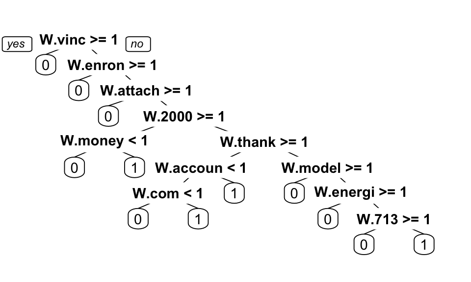

```r
prp(spamCART)
```

#### Problem 3.4 - Building Machine Learning Models

What is the training set accuracy of spamLog, using a threshold of 0.5 for predictions?

```r
table(predLogTrain>0.5,train$spam)
```

```
##
##            0    1
##   FALSE 3052    4
##   TRUE     0  954
```

```r
sum(as.numeric(predLogTrain>0.5)==train$spam)/nrow(train)
```

```
## [1] 0.9990025
```

#### Problem 3.5 - Building Machine Learning Models

What is the training set AUC of spamLog?

```r
ROCRpred = prediction(predLogTrain, train$spam)
as.numeric(performance(ROCRpred, "auc")@y.values)
```

```
## [1] 0.9999959
```

#### Problem 3.6 - Building Machine Learning Models

What is the training set accuracy of spamCART, using a threshold of 0.5 for predictions? (Remember that if you used the type=“class” argument when making predictions, you automatically used a threshold of 0.5. If you did not add in the type argument to the predict function, the probabilities are in the second column of the predict output.)

```r
predCARTTrain = predict(spamCART,train)
sum(as.numeric(predCARTTrain[,2]>0.5)==train$spam)/nrow(train)
```

```
## [1] 0.942394
```

#### Problem 3.7 - Building Machine Learning Models

What is the training set AUC of spamCART? (Remember that you have to pass the prediction function predicted probabilities, so don’t include the type argument when making predictions for your CART model.)

```r
ROCRpred = prediction(predCARTTrain[,2], train$spam)
as.numeric(performance(ROCRpred, "auc")@y.values)
```

```
## [1] 0.9696044
```

#### Problem 3.8 - Building Machine Learning Models

What is the training set accuracy of spamRF, using a threshold of 0.5 for predictions? (Remember that your answer might not match ours exactly, due to random behavior in the random forest algorithm on different operating systems.)

```r
predRFTrain = predict(spamRF,train,type="prob")
sum(as.numeric(predRFTrain[,2]>0.5)==train$spam)/nrow(train)
```

```
## [1] 0.9985037
```

#### Problem 3.9 - Building Machine Learning Models

What is the training set AUC of spamRF? (Remember to pass the argument type=“prob” to the predict function to get predicted probabilities for a random forest model. The probabilities will be the second column of the output.)

```r
ROCRpred = prediction(predRFTrain[,2], train$spam)
as.numeric(performance(ROCRpred, "auc")@y.values)
```

```
## [1] 0.9999959
```

#### Problem 3.10 - Building Machine Learning Models

Which model had the best training set performance, in terms of accuracy and AUC?

- **Logistic regression**
- CART
- Random forest

#### Problem 4.1 - Evaluating on the Test Set

Obtain predicted probabilities for the testing set for each of the models, again ensuring that probabilities instead of classes are obtained.

What is the testing set accuracy of spamLog, using a threshold of 0.5 for predictions?

```r
predLogTest = predict(spamLog,test,type = "response")
sum(as.numeric(predLogTest>0.5)==test$spam)/nrow(test)
```

```
## [1] 0.9505239
```

#### Problem 4.2 - Evaluating on the Test Set

What is the testing set AUC of spamLog?

```r
ROCRpred = prediction(predLogTest, test$spam)
as.numeric(performance(ROCRpred, "auc")@y.values)
```

```
## [1] 0.9627517
```

#### Problem 4.3 - Evaluating on the Test Set

What is the testing set accuracy of spamCART, using a threshold of 0.5 for predictions?

```r
predCARTTest = predict(spamCART,test,type="prob")
sum(as.numeric(predCARTTest[,2]>0.5)==test$spam)/nrow(test)
```

```
## [1] 0.9394645
```

#### Problem 4.4 - Evaluating on the Test Set

What is the testing set AUC of spamCART?

```r
ROCRpred = prediction(predCARTTest[,2], test$spam)
as.numeric(performance(ROCRpred, "auc")@y.values)
```

```
## [1] 0.963176
```

#### Problem 4.5 - Evaluating on the Test Set

What is the testing set accuracy of spamRF, using a threshold of 0.5 for predictions?

```r
predRFTest = predict(spamRF,test,type="prob")
sum(as.numeric(predRFTest[,2]>0.5)==test$spam)/nrow(test)
```

```
## [1] 0.975553
```

#### Problem 4.6 - Evaluating on the Test Set

What is the testing set AUC of spamRF?

```r
ROCRpred = prediction(predRFTest[,2], test$spam)
as.numeric(performance(ROCRpred, "auc")@y.values)
```

```
## [1] 0.997768
```

#### Problem 4.7 - Evaluating on the Test Set

Which model had the best testing set performance, in terms of accuracy and AUC?

- Logistic regression
- CART
- **Random forest**

#### Problem 4.8 - Evaluating on the Test Set

Which model demonstrated the greatest degree of overfitting?

- **Logistic regression**
- CART
- Random forest